# 2 Intelligent Agents

## 2.1 Agents and Environments

### What is Agent

An **agent** is anything that can be viewed as perceiving its **environment** through **sensors** and acting upon that environment through **actuators**

[figure not shown]

Agents interact with environments through sensors and actuators.

- **Organizations** Microsoft, European Union, Real Madrid FC, an ant colony,…
- **People** teacher, physician, stock trader, engineer, researcher, travel agent, farmer, waiter…
- **Computers/devices** thermostat, user interface, airplane controller, network controller, game, advising system, tutoring system, diagnostic assistant, robot, Google car, Mars rover…
- **Animals** dog, mouse, bird, insect, worm, bacterium, bacteria…

[figure not shown]

- **Percept** to refer to the agent’s perceptual inputs at any given instant.
- **Action** to refer to agent’s behavior.
- **Percept sequence** is a sequence of all past and present percepts the agent has ever perceived.
- An action is described by the **agent function** that maps any given percept sequence to an action
  $$f:P^{*}\to A$$
- **Agent program**: the implementation of the agent function
  $$agent=architecture+program$$

### Vacuum-cleaner

[figure not shown]

- Percepts: location and contents, e.g., $[A,Dirty]$
- Actions: $Left$, $Right$, $Suck$, $NoOp$
- Function:

  | **Percept sequence** | **Action** |
  | --- | --- |
  | $[A,Clean]$ | $Right$ |
  | $[A,Dirty]$ | $Suck$ |
  | $[B,Clean]$ | $Left$ |
  | $[B,Dirty]$ | $Suck$ |
  | $[A,Clean],[A,Clean]$ | $Right$ |
  | $\vdots$ | $\vdots$ |

```
function Reflex-Vaccum-Agent([location,status]) returns an action

    if status = Dirty then return Suck
    else if location = A then return Right
    else if location = B then return Left
```

- What is the *right* function?
- Can it be implemented in a small agent program?

## 2.2 Good Behavior: The Concept of Rationality

### Rationality

- A **rational agent** is one that does the **right thing**
- What is **right thing**?
  - When an agent is plunked down in an environment, it generates a sequence of actions according to the percepts it receives. This sequence of actions causes the environment to go through a sequence of states. If the sequence is desirable, then the agent has performed well
  - **Performance measure** evaluates any given sequence of **environment states** (not **agent states**)

**A rule of thumb**

It is better to design performance measures according to what one actually wants in the environment, rather than according to how one thinks the agent should behave

Rational depends on four things:

- The **performance measure** that defines the criterion of success.
- The agent’s **prior knowledge** of the environment.
- The **actions** that the agent can perform.
- The agent’s **percept sequence** to date.

**Definition of a rational agent**

For each possible percept sequence, a rational agent should select an action that is expected to maximize its performance measure, given the evidence provided by the percept sequence and whatever built-in knowledge the agent has*.*

### Omniscience, learning, and autonomy

- Rational $\neq$ omniscient, percepts may not supply all relevant information
- Rational $\neq$ clairvoyant, action outcomes may not be as expected
- Hence, rational $\neq$ successful
- Rational $\implies$ exploration, learning, autonomy

#### Omniscience vs. Rationality

| Omniscience | Rationality |
| --- | --- |
| Knows the actual outcome of its actions in advance | Rationality maximizes *expected* performance, while perfection maximizes *actual* performance |
| Perfection but not practical |  |

#### Information gathering

- **Information gathering** by doing actions in order to modify future percepts or exploration
- This is an important part of rationality

#### Learning

- A rational agent also has to **learn** as much as possible from what it perceives.
  - The agent’s initial configuration may be modified and augmented as it gains experience.
- There are extreme cases in which the environment is completely known **a priori**.

#### Autonomy

- A rational agent should be **autonomous** – Learn what it can to compensate for partial or incorrect prior knowledge.
  - If an agent just relies on the prior knowledge of its designer rather than its own percepts then the agent lacks autonomy

## 2.3 The Nature of Environments

### The task environment

- **Task environments** are essentially the “problems” to which rational agents are the “solutions”
  - The flavor of the task environment directly affects the appropriate design for the agent program
- **Task environment** includes the **PEAS** (**P**erformance, **E**nvironment, **A**ctuators, **S**ensors) description
- In designing an agent, the first step must always be to specify the task environment as fully as possible.

### An example: Automated taxi driver

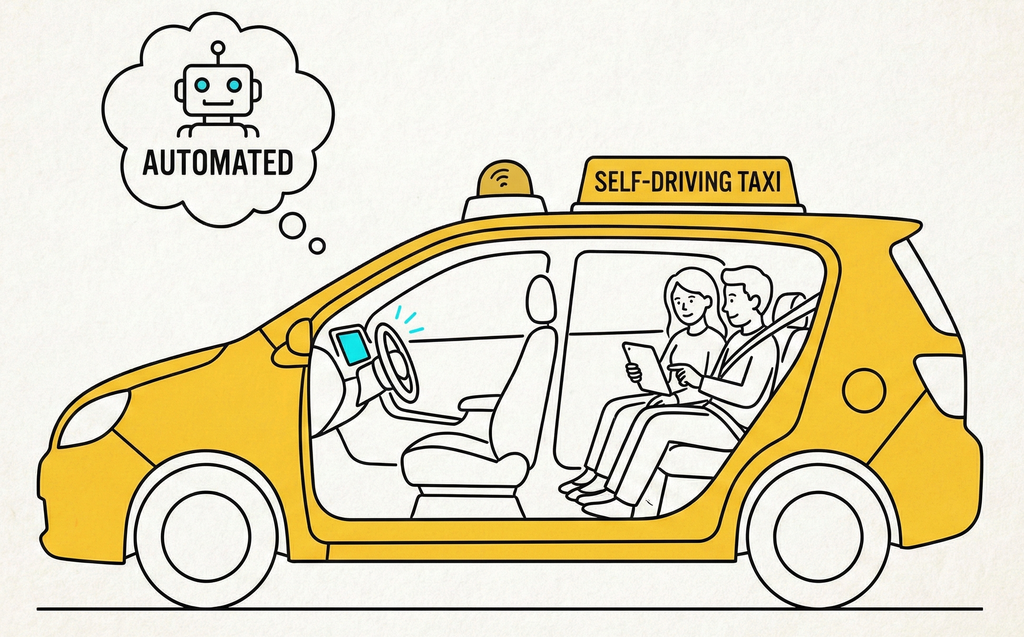

- **Performance measure**
  - safety, destination, profits, legality, comfort, $\ldots$
- **Environment**
  - streets/freeways, traffic, pedestrians, weather, $\ldots$
- **Actuators**
  - steering, accelerator, brake, horn, speaker/display, $\ldots$
- **Sensors**
  - video, accelerometers, gauges, engine sensors, keyboard, GPS, $\ldots$

### Software agents

- Sometimes, the environment may not be the real world.
  - Flight simulator, video games, Internet
  - They are all artificial but very complex environments
- Those agents working in these environments are called **software agents** (**softbots**).
  - All parts of the agent are software.

### Properties of task environments

- Fully observable vs. partially observable
- Single agent vs. multiagent
- Deterministic vs. stochastic
- Episodic vs. sequential
- Discrete vs. continuous
- Static vs. dynamic
- Known vs. unknown

### Fully observable vs. partially observable

- Fully observable: The agent’s sensory gives it access to the complete state of the environment.
  - The agent need not maintain internal state to keep track of the world.
- Partially observable
  - Noisy and inaccurate sensors
  - Parts of the state are simply missing from the sensor data
- Unobservable: The agent has no sensors at all

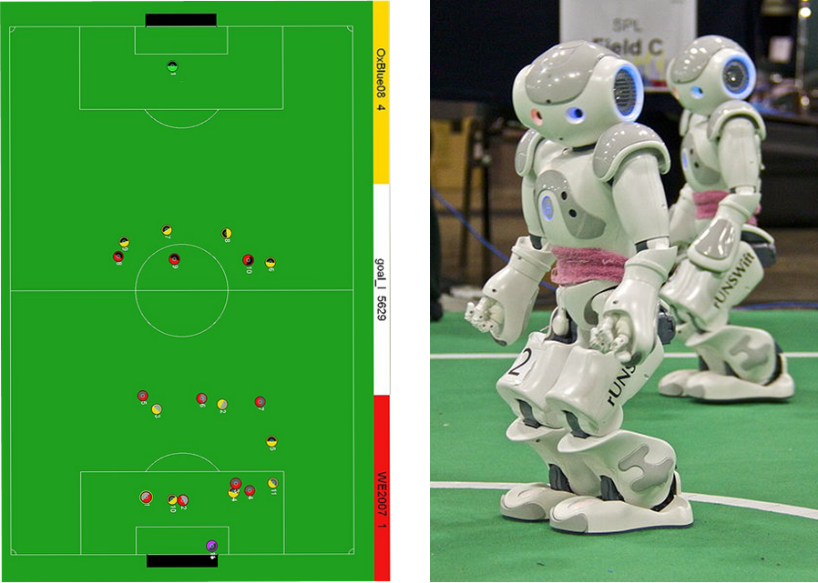

### Single agent vs. multiagent

- Single agent: An agent operates by itself in an environment.
  - Solving crossword $\rightarrow$ single agent, playing chess $\rightarrow$ two agents
- Which entities must be viewed as agents?
- Competitive vs. Cooperative multiagent environment
  - Playing chess $\rightarrow$ competitive, driving on road $\rightarrow$ cooperative

[figure not shown]

### Deterministic vs. stochastic

- Deterministic: The next state of the environment is completely determined by the current state and the action executed by the agent.
  - The vacuum world $\rightarrow$ deterministic, driving on road $\rightarrow$ stochastic
- Most real situations are so complex that they must be treated as stochastic.

[figure not shown]

### Episodic vs. sequential

- Episodic: The agent’s experience is divided into atomic episodes, in each of which the agent receives a percept and then performs a single action
- Sequential: A current decision could affect future decisions

[figure not shown]

### Discrete vs. continuous

- The discrete/continuous distinction applies to the *state* of the environment, to the way *time* is handled, and to the *percepts* and *actions* of the agent

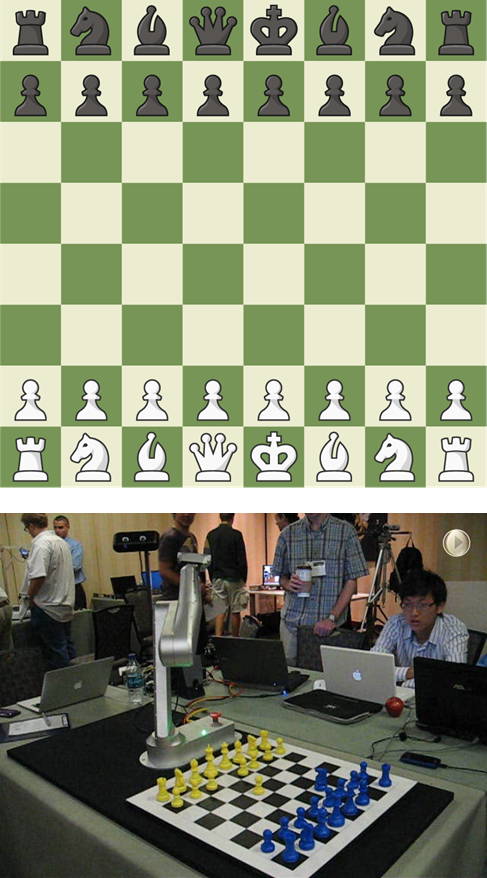

### Static vs. dynamic

- **Static**: The environment is unchanged while an agent is deliberating.
  - Crossword puzzles $\rightarrow$ static, taxi driving $\rightarrow$ dynamic
- **Semidynamic**: The environment itself does not change with the passage of time but the agent’s performance score does
  - Chess playing with a clock

[figure not shown]

### Known vs. unknown

- **Known environment**: the outcomes (or outcome probabilities if the environment is stochastic) for all actions are given.
- **Unknown environment**: the agent needs to learn how it works to make good decisions.

[figure not shown]

### Examples of different environments

[figure not shown]

## 2.4 The Structure of Agents

### The Structure of Agents

$$agent=architecture+program$$

- **Architecture**: some sort of computing device with physical sensors and actuators that this program will run on.
  - Ordinary PC, robotic car with several onboard computers, cameras, and other sensors, etc.
- **Program** has to be appropriate for the architecture.
  - Program: Walk action $\rightarrow$ Architecture: legs

### The agent programs

- A trivial agent program: keep track of the percept sequence and index into a table of actions to decide what to do.

```
function Table-Driven-Agent(percept) returns an action

persistent:
        percepts: a sequence, initially empty
        table: a table of actions,
               indexed by percept sequences,
               initially fully specified

    append percept to the end of percepts
    action ← Lookup(percepts, table)
    return action
```

- The table-driven approach to agent construction is doomed to failure
- Let $P$ be the set of possible percepts and
- Let $T$ be the lifetime of the agent (the total number of percepts it will receive).
- The lookup table will contain $\sum_{t=1}^{T}\left|P\right|^{t}$ entries $\to$ very huge table

### Agent types

Four basic types in order of increasing generality:

- Simple reflex agents
- Model-based reflex agents
- Goal-based agents
- Utility-based agents

### Simple reflex agents

- The simplest kind of agent, but of limited intelligence
- Select actions based on the current percept, ignoring the rest of the percept history
- The connection from percept to action is represented by condition-action rules.

  **IF** *current percept* **THEN** *action*
- Limitations
  - Knowledge sometimes cannot be stated explicitly $\rightarrow$ low applicability
  - Work only if the environment is fully observable

[figure not shown]

```
function Simple-Reflex-Agent(percept) returns an action

persistent:
        rules: a set of condition-action rules

    state ← Interpret-Input(percept)
    rule ← Rule-Match(state, rules)
    action ← rule.Action
    return action
```

### Model-based reflex agents

- Partially observability $\rightarrow$ the agent has to keep track of an internal state
  - Depend on the percept history and reflect some of the unobserved aspects
- The agent program updates the internal state information as time goes by by encoding two kinds of knowledge
  - How the world evolves independently of the agent
  - How the agent’s actions affect the world

[figure not shown]

```
function Model-Based-Reflex-Agent(percept) returns an action

persistent:
        state: the agent's current conception of the world state
        model: a description of how the next state depends on current state and action
        rules: a set of condition-action rules
        action: the most recent action, initially none

    state ← Update-State(state, action, percept, model)
    rule ← Rule-Match(state, rules)
    action ← rule.action
    return action
```

### Goal-based agents

- Current state of the environment is always not enough
- The agent further needs some sort of goal information that describes situations that are desirable.
- Less efficient but more flexible

[figure not shown]

### Utility-based agents

- Goals alone are not enough to generate high-quality behavior in most environments
- Many action sequences to get the goals, some are better and some worse
- An agent’s **utility function** is essentially an internalization of the performance measure.
  - Goal $\rightarrow$ success, utility $\rightarrow$ degree of success (how successful it is)

[figure not shown]

### Learning agents

A learning agent is divided into four conceptual components

- **Learning element** $\rightarrow$ Making improvement
- **Performance element** $\rightarrow$ Selecting external actions
- **Critic** $\rightarrow$ Tells the Learning element how well the agent is doing with respect to fixed performance standard. (Feedback from user or examples, good or not?)
- **Problem generator** $\rightarrow$ Suggest actions that will lead to new and informative experiences

[figure not shown]

### Component representations

- Three basic representations: **atomic**, **factored**, and **structured**

[figure not shown]

Three ways to represent states and the transitions between them. (a) Atomic representation: a state (such as B or C) is a black box with no internal structure; (b) Factored representation: a state consists of a vector of attribute values; values can be Boolean, real-valued, or one of a fixed set of symbols. (c) Structured representation: a state includes objects, each of which may have attributes of its own as well as relationships to other objects.

## 2.5 References

[video not shown]